# Baseball Data Analysis

### Standard Setup Code

```python
import matplotlib.pyplot as plt
import pandas as pd
import seaborn as sns

%pylab inline

def correlation(x,y):
    return (x*y).mean()
```

## Overview of Statistics in Baseball

### Scope of Analysis

The data used in this analysis will be all Major League Baseball teams after the year of 1947.

*Note: Sacrifice Flies and Hit by Pitches were not recorded until the year 2000. Zeroes will be assumed for all seasons between 1947 and 1999*

```python
#Load overall team statistics and fill in blanks with zeroes
teams_df = pd.read_csv('baseballdatabank-master\core\Teams.csv')
len(teams_df)
teams_df.fillna(0)
```

[output not shown]

2805 rows × 48 columns

```python
#limiting scope of dataset to teams on or after 1947
teams_after_1947_df = teams_df[teams_df.yearID >= 1947]
teams_after_1947_df.fillna(0,inplace=True)
len(teams_after_1947_df)
```

```
1670
```

## Statistics Relating to a Team's Overall Success

There are three key facets to the game of baseball: 1) the ability to hit the ball, usually resulting in more runs, 2) the ability to limit the other team from hitting the ball, usually resulting in less runs, and 3) the ability to make routine plays in the field even if the ball has been hit. We will look at one key statistic in each of these areas to evalute which one has the highest correlation to a team's winning percentage.

### Batting as Related to a Team's Success

In this section, we will calculate the team's ability to hit the ball by calculating the team's OPS (On-base plus slugging)

#### Definitions

**On-base percentage (OBP)** = (Hits + Walks + Hit by Pitch) / (At Bats + Walks + Hit by Pitch + Sacrifice Flies)

```python
def get_OBP(df):
    OBP = (df['H'] + df['BB'] + df['HBP'])/(df['AB'] + df['BB'] + df['HBP'] + df['SF'])
    return OBP
```

**Slugging Percentage (SLG)** = (Singles + (2 x Doubles) + (3 X Triples) + (4 * Home Runs)) / At-Bats OPS = OBP + SLG

```python
def get_slugging_pct(df):
    slugging_pct=((df['H']-df['2B']-df['3B']-df['HR']) \
               + (2*df['2B']) + (3*df['3B']) + (4*df['HR'])) \
               / (df['AB'])
    return slugging_pct
```

**OPS** = OBP + SLG

```python
batting_avg = get_slugging_pct(teams_after_1947_df)
on_base_pct = get_OBP(teams_after_1947_df)
OPS = batting_avg + on_base_pct
```

#### Statistical Correlation Between OPS and Wins (Pearson's R)

```python
std_OPS = (OPS - OPS.mean()) / OPS.std(ddof=0)
std_W = (teams_after_1947_df['W'] - teams_after_1947_df['W'].mean())/ teams_after_1947_df['W'].std(ddof=0)
OPS_W_correlation = correlation(std_OPS,std_W)
print OPS_W_correlation
```

```
0.437578917259
```

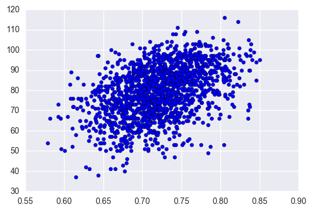

```python
plt.scatter(OPS,teams_after_1947_df['W'])
```

### Pitching as Related to a Team's Success

In this section, we will calculate the team's ability to pitch by calculating the team's WHIP (Walks and Hits Per Inning Pitched)

#### Definitions

**Walks and Hits Per Inning Pitched (WHIP)** = (Walks + Hits) / Inning Pitched

```python
def get_WHIP(df):
    WHIP = (df['BBA'] + df['HA'])/(df['IPouts'] / 3)
    return WHIP
```

```python
WHIP = get_WHIP(teams_after_1947_df)
```

#### Statistical Correlation Between WHIP and Wins (Pearson's R)

```python
std_WHIP = (WHIP-WHIP.mean()) / (WHIP.std(ddof=0))
WHIP_W_correlation = correlation(std_WHIP,std_W)
print WHIP_W_correlation
```

```
-0.543845762037
```

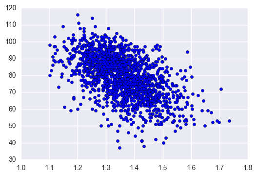

```python
WHIP_W_Plot = pd.DataFrame(dict(std_WHIP = std_WHIP, std_W = std_W))
plt.scatter(WHIP,teams_after_1947_df['W'])
```

### Fielding as Related to a Team's Success

In this section, we will use the provided Fielding Percentage (FP)

#### Statistical Correlation Between FP and Wins (Pearson's R)

```python
std_FP = (teams_after_1947_df['FP'] - teams_after_1947_df['FP'].mean())/teams_after_1947_df['FP'].std(ddof=0)
FP_W_correlation = correlation(std_FP,std_W)
print FP_W_correlation
```

```
0.232048158798
```

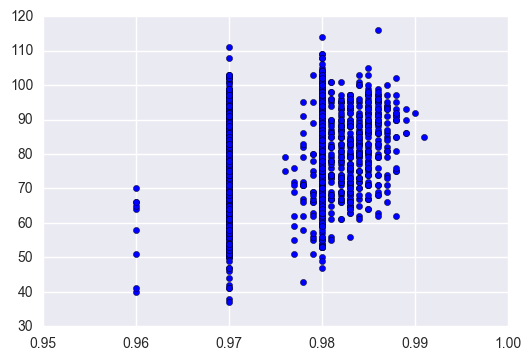

```python
plt.scatter(teams_after_1947_df['FP'],teams_after_1947_df['W'])
```

### Reanalyzing Fielding Percentage

I wanted to analyze the data with the only teams after the year 1999 after seeing this.

```python
#limit only to teams in year 2000 and after
teams_after_2000_df = teams_df[teams_df.yearID >= 2000]
teams_after_2000_df.fillna(0,inplace=True)
```

```python
std_FP = (teams_after_2000_df['FP'] - teams_after_2000_df['FP'].mean())/teams_after_2000_df['FP'].std(ddof=0)
FP_W_correlation = correlation(std_FP,std_W)
print FP_W_correlation
```

```
0.336314032667
```

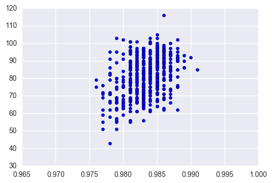

```python
plt.scatter(teams_after_2000_df['FP'],teams_after_2000_df['W'])
```

### Conclusion

Modern Major League Baseball is known to use advanced statiscal analysis to gain an advantage in a sport that has teams playing 162 games a year needing every little edge possible. The amount and types of data grow each year as technology is embraced and we tried to use some of those newer statistics to analyze teams over the past 70 years or so.

Using a standard correlation calculation, we wanted to see whether the new baselines of batting, pitching, and fielding statistics correlated with a team's winning percentage. Between On-Base Plus Slugging (OPS), for batting, Walks and Hits Per Inning Pitches (WHIP), for pitching, and Fielding Percantage (FP), for fielding, WHIP showed the strongest correlation with a team's winning percentage.

So, the old adage is that pitching wins championships seems to hold true? Not exactly. For one, we only looked at regular season win totals, so there's no telling if the teams with the highest win percentage won the championship that year as well. Also, there could be other outside contributing factors as well. Teams with a low WHIP might have been influenced more by good defense than good pitching, but it is hard to say at this point.